# Table of Contents

# Correlation age -frequence d'achat

```python
#Pour repondre à  cette question nous allons d'abord  recharger  la table qui contients  les elements recquis
#Nous allons ajouter a notre DF client  les elements de  la table d'origine qui nous interesse
#ces elemnts sont  la variablle date et  celle des sessions id
#Nous allons  nous appuyer sur  la table des clients grouppée
#Nous allons  grouppés ensuite la table transaction  par  session
#Et enfin fusionner  les deux tables
dfsession = datap4V.groupby(by = 'session_id').sum()
dfsession.head()
```

| session_id | price | categ | birth | age |
| --- | --- | --- | --- | --- |
| s_1 | 11.99 | 0.0 | 1967 | 54 |
| s_10 | 26.99 | 1.0 | 1970 | 51 |
| s_100 | 33.72 | 0.0 | 3956 | 86 |
| s_1000 | 39.22 | 0.0 | 7956 | 128 |
| s_10000 | 41.49 | 1.0 | 5967 | 96 |

```python
#Essayons d'avoir  plus d'infos sur cette  nouvelle DF
dfsession.info()
dfsession.describe()
```

```
<class 'pandas.core.frame.DataFrame'>
Index: 169173 entries, s_1 to s_99998
Data columns (total 4 columns):
 #   Column  Non-Null Count   Dtype
---  ------  --------------   -----
 0   price   169173 non-null  float64
 1   categ   169173 non-null  float64
 2   birth   169173 non-null  int64
 3   age     169173 non-null  int64
dtypes: float64(2), int64(2)
memory usage: 6.5+ MB
```

|  | price | categ | birth | age |
| --- | --- | --- | --- | --- |
| count | 169173.000000 | 169173.000000 | 169173.000000 | 169173.000000 |
| mean | 34.264202 | 0.856159 | 3936.555520 | 85.936089 |
| std | 31.872538 | 0.980733 | 2524.573036 | 58.044687 |
| min | 0.620000 | 0.000000 | 1929.000000 | 17.000000 |
| 25% | 15.200000 | 0.000000 | 1971.000000 | 50.000000 |
| 50% | 25.560000 | 1.000000 | 3918.000000 | 69.000000 |
| 75% | 42.980000 | 1.000000 | 5898.000000 | 110.000000 |
| max | 539.230000 | 10.000000 | 27888.000000 | 858.000000 |

```python
#Maintenant  que  nous avons  grouppé  autour de session  nous allons  y ajouter   les dates
#Nous allons atravers  une  jointure interne lier  les deux tables
dfsession_jn = pd.merge(dfsession,datap4V ,on='session_id' ,how = 'inner')
dfsession_jn.head()
```

|  | session_id | price_x | categ_x | birth_x | age_x | id_prod | price_y | categ_y | date | client_id | sex | birth_y | age_y | ageclas |
| --- | --- | --- | --- | --- | --- | --- | --- | --- | --- | --- | --- | --- | --- | --- |
| 0 | s_1 | 11.99 | 0.0 | 1967 | 54 | 0_1259 | 11.99 | 0.0 | 2021-03-01 00:01:07.843138 | c_329 | f | 1967 | 54 | (50, 60] |
| 1 | s_10 | 26.99 | 1.0 | 1970 | 51 | 1_635 | 26.99 | 1.0 | 2021-03-01 00:10:33.163037 | c_2218 | f | 1970 | 51 | (50, 60] |
| 2 | s_100 | 33.72 | 0.0 | 3956 | 86 | 0_1451 | 19.99 | 0.0 | 2021-03-01 04:43:58.025677 | c_3854 | f | 1978 | 43 | (40, 50] |
| 3 | s_100 | 33.72 | 0.0 | 3956 | 86 | 0_1030 | 13.73 | 0.0 | 2021-03-01 04:12:43.572994 | c_3854 | f | 1978 | 43 | (40, 50] |
| 4 | s_1000 | 39.22 | 0.0 | 7956 | 128 | 0_1590 | 18.93 | 0.0 | 2021-03-03 02:49:03.169115 | c_1014 | m | 1989 | 32 | (30, 40] |

```python
#appliquer et  faire un
dfsessionRv = dfsession_jn.groupby(by = 'client_id').agg(['count'])
dfsessionRv.head()
```

| client_id | session_id count | price_x count | categ_x count | birth_x count | age_x count | id_prod count | price_y count | categ_y count | date count | sex count | birth_y count | age_y count | ageclas count |
| --- | --- | --- | --- | --- | --- | --- | --- | --- | --- | --- | --- | --- | --- |
| c_1 | 20 | 20 | 20 | 20 | 20 | 20 | 20 | 20 | 20 | 20 | 20 | 20 | 20 |
| c_10 | 28 | 28 | 28 | 28 | 28 | 28 | 28 | 28 | 28 | 28 | 28 | 28 | 28 |
| c_100 | 6 | 6 | 6 | 6 | 6 | 6 | 6 | 6 | 6 | 6 | 6 | 6 | 6 |
| c_1000 | 56 | 56 | 56 | 56 | 56 | 56 | 56 | 56 | 56 | 56 | 56 | 56 | 56 |
| c_1001 | 58 | 58 | 58 | 58 | 58 | 58 | 58 | 58 | 58 | 58 | 58 | 58 | 58 |

```python
#Pour traiter  cette question  , nous allons selectionner  les coonnes qui nous  interessent
#A partir d'un nouveau  Df  nous allon faire  les operations idoines

dffreq = datap4V[['session_id','client_id','price','birth','date']]
dffreq.head()
```

|  | session_id | client_id | price | birth | date |
| --- | --- | --- | --- | --- | --- |
| 0 | s_18746 | c_4450 | 4.99 | 1977 | 2021-04-10 18:37:28.723910 |
| 1 | s_140787 | c_5433 | 4.99 | 1981 | 2021-12-27 11:11:12.123067 |
| 2 | s_110736 | c_857 | 4.99 | 1985 | 2021-10-27 04:56:38.293970 |
| 3 | s_57626 | c_3679 | 4.99 | 1989 | 2021-07-04 06:43:45.676567 |
| 4 | s_92165 | c_1609 | 4.99 | 1980 | 2021-09-19 08:45:43.735331 |

# client atypique

```python
#Nous allons agreger  cette DF sur  la variable session_id
dffreqgr = dffreq.groupby(["client_id","session_id"])["price"].sum()
dffreqgr.head()
```

```
client_id  session_id
c_1        s_105105       7.99
           s_114737      92.62
           s_120172      44.29
           s_134971      10.30
           s_136532      13.78
Name: price, dtype: float64
```

```python
#Nous  reduisons  le df  en  l'agregeant autour des clients
#Ainsi  nous  obtenons  pour chaque client  le montant  de son panier  moyen
#cela n ous  permet  de cerner  les  ecarts des commandes des clients de sorte  à typer   nos clients  par session
#
dfclientaty=dffreqgr.groupby('client_id').sum()
dfclientaty.head()
```

```
client_id
c_1        300.65
c_10       586.18
c_100      222.87
c_1000     980.02
c_1001    1102.45
Name: price, dtype: float64
```

```python
#Mais  ce tabmeau  ne nous permet de  bien cerner  les disparités de commandes de  notre  base clientele.
#Nous decidons  de clzsser  en ordre decroissant  les achats de  notre clientélé sur  l'année
dfclientaty.sort_values(ascending=False).head(10)
```

```
client_id
c_1609    162007.34
c_4958    144257.21
c_6714     73197.34
c_3454     54442.92
c_7959      2564.25
c_4491      2540.53
c_8026      2537.67
c_2140      2527.01
c_8392      2515.98
c_7421      2511.98
Name: price, dtype: float64
```

Cette liste nous permet de cerner une grande disparité entre les clients meme les plus fideles de notre entreprise Les transactions sont telleemnt importantes que nous pouvons imaginer sur des consommateurs lambda ne pourraient consommer autant de produits. Nous pouvons imaginer que certains entrepreneurs composent notre base clientéle et il est important de segmenter cete base.

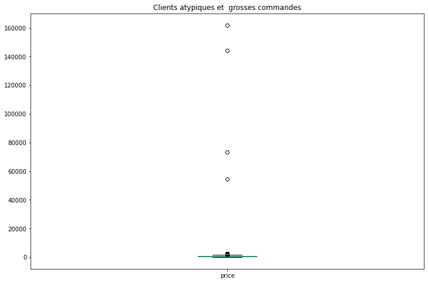

```python
#representons visuellement cette distribution
plt.figure(figsize=(12,8))
dfclientaty.plot.box()
plt.title('Clients atypiques et  grosses commandes')
plt.show()
plt.savefig('Clients atypiques de  Rester .jpg')
```

Sur ce graphe on peut bien cerner que la distribution montre un aplatissement total et que les outliers representant 4 clients se distinguent nettement. ils sont très au dessus en terme de poids financier en comparaisont aux autres clients.

```python
#Nous allons  sortir  les clients qui semblent atypiques
dfclaty = dffreqgr.sort_values(ascending=False)[:10]
dfclaty.head()
```

```
client_id  session_id
c_8345     s_123227      539.23
c_3241     s_83158       535.17
c_667      s_150439      496.22
c_4658     s_170478      476.19
c_4958     s_165683      473.98
Name: price, dtype: float64
```

```python
#testons  les clients  qui achetent  beaucoup
cliaty =datap4V[(datap4V['client_id'] == 'c_8345')]
cliaty.head()
```

|  | id_prod | price | categ | date | session_id | client_id | sex | birth | age | ageclas |
| --- | --- | --- | --- | --- | --- | --- | --- | --- | --- | --- |
| 50754 | 1_264 | 16.07 | 1.0 | 2021-06-19 09:53:03.499741 | s_50772 | c_8345 | f | 1993 | 28 | (20, 30] |
| 56133 | 0_1537 | 5.99 | 0.0 | 2022-01-20 01:30:51.239212 | s_152354 | c_8345 | f | 1993 | 28 | (20, 30] |
| 125717 | 1_381 | 15.99 | 1.0 | 2022-02-17 23:31:08.343778 | s_166823 | c_8345 | f | 1993 | 28 | (20, 30] |
| 152405 | 1_708 | 23.06 | 1.0 | 2021-04-13 19:25:01.752249 | s_20134 | c_8345 | f | 1993 | 28 | (20, 30] |
| 164772 | 0_1001 | 4.99 | 0.0 | 2022-01-20 00:54:15.900490 | s_152354 | c_8345 | f | 1993 | 28 | (20, 30] |

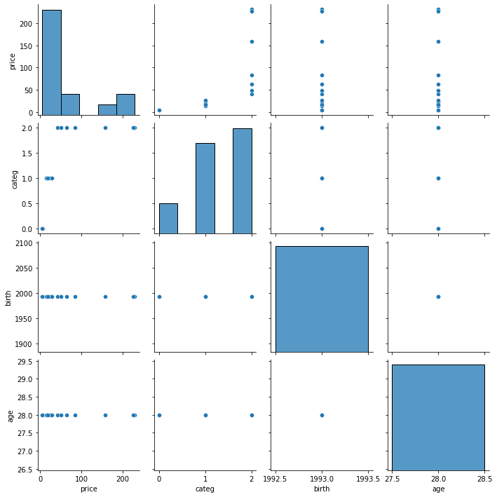

```python
#Essayons d'afficher visuellemnt  un graphe qui montre  les clients atypiques
sns.pairplot(cliaty)
```

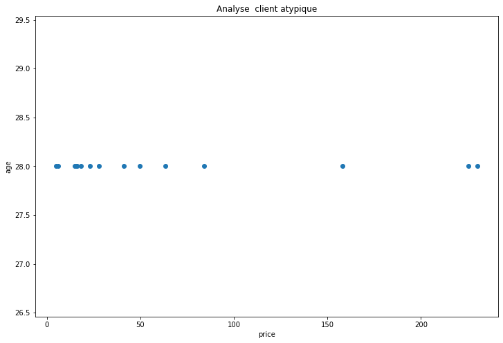

```python
#Precisons  nos  representations
plt.figure(figsize=(12,8))
plt.plot(cliaty['price'],cliaty['age'],'o',alpha=2.0)
plt.title('Analyse  client atypique')
plt.xlabel('price')
plt.ylabel('age')
plt.show()
plt.savefig('correlation Achatclientatypique.jpg')
```

```python
#Verifions que la session id ne comporte  pas des doublons
#Mais avant  explorons  la table
dffreq.info()
dffreq.describe()
```

```
<class 'pandas.core.frame.DataFrame'>
RangeIndex: 336713 entries, 0 to 336712
Data columns (total 5 columns):
 #   Column      Non-Null Count   Dtype
---  ------      --------------   -----
 0   session_id  336713 non-null  object
 1   client_id   336713 non-null  object
 2   price       336713 non-null  float64
 3   birth       336713 non-null  int64
 4   date        336713 non-null  datetime64[ns]
dtypes: datetime64[ns](1), float64(1), int64(1), object(2)
memory usage: 12.8+ MB
```

|  | price | birth |
| --- | --- | --- |
| count | 336713.000000 | 336713.000000 |
| mean | 17.215189 | 1977.823568 |
| std | 17.855445 | 13.524433 |
| min | 0.620000 | 1929.000000 |
| 25% | 8.610000 | 1971.000000 |
| 50% | 13.900000 | 1980.000000 |
| 75% | 18.990000 | 1987.000000 |
| max | 300.000000 | 2004.000000 |

```python
#Nous allons verifier  si  il  ya pas de doublons  à partir de  la table d'origine
#Pour cela nous faisons  un test  sur  une session d'un client  le c1
#Dans  le test  , nous sommons  à la main  la colonne  price  et  trouvons qu'il equivaut  à 92,67 , le  numero  de  la session test

sestest = datap4V[(datap4V['session_id'] == 's_114737')]
sestest.head()
```

|  | id_prod | price | categ | date | session_id | client_id | sex | birth | age | ageclas |
| --- | --- | --- | --- | --- | --- | --- | --- | --- | --- | --- |
| 52025 | 0_1410 | 14.85 | 0.0 | 2021-11-04 18:13:43.694570 | s_114737 | c_1 | m | 1955 | 66 | (60, 70] |
| 110119 | 0_1568 | 4.00 | 0.0 | 2021-11-04 18:02:39.561078 | s_114737 | c_1 | m | 1955 | 66 | (60, 70] |
| 231407 | 0_1747 | 3.99 | 0.0 | 2021-11-04 18:37:48.745436 | s_114737 | c_1 | m | 1955 | 66 | (60, 70] |
| 295371 | 0_1880 | 14.91 | 0.0 | 2021-11-04 18:37:01.482109 | s_114737 | c_1 | m | 1955 | 66 | (60, 70] |
| 317762 | 2_208 | 54.87 | 2.0 | 2021-11-04 17:28:13.934070 | s_114737 | c_1 | m | 1955 | 66 | (60, 70] |

```python
#Nous allons travailler avec  la table  dffreq  obtenue  plus haut
#Nous allons garder  les colonnes qui nous interessent  en  enlevant  la colonne  prix
dffreq.head()
```

|  | session_id | client_id | price | birth | date |
| --- | --- | --- | --- | --- | --- |
| 0 | s_18746 | c_4450 | 4.99 | 1977 | 2021-04-10 18:37:28.723910 |
| 1 | s_140787 | c_5433 | 4.99 | 1981 | 2021-12-27 11:11:12.123067 |
| 2 | s_110736 | c_857 | 4.99 | 1985 | 2021-10-27 04:56:38.293970 |
| 3 | s_57626 | c_3679 | 4.99 | 1989 | 2021-07-04 06:43:45.676567 |
| 4 | s_92165 | c_1609 | 4.99 | 1980 | 2021-09-19 08:45:43.735331 |

```python
#Faisons  une copie  de cette  noubelle table  afin de faire  les  operations dessus
dffreqV= dffreq.copy()
#Nous allons  modifier  notre table en gardant que certaines colonnes  qui nous  interessent
dffreqVR = dffreqV.drop(columns ='price')
dffreqVR.head()
```

|  | session_id | client_id | birth | date |
| --- | --- | --- | --- | --- |
| 0 | s_18746 | c_4450 | 1977 | 2021-04-10 18:37:28.723910 |
| 1 | s_140787 | c_5433 | 1981 | 2021-12-27 11:11:12.123067 |
| 2 | s_110736 | c_857 | 1985 | 2021-10-27 04:56:38.293970 |
| 3 | s_57626 | c_3679 | 1989 | 2021-07-04 06:43:45.676567 |
| 4 | s_92165 | c_1609 | 1980 | 2021-09-19 08:45:43.735331 |

```python
#Nous faisons  une restriction des colonnes  pour garder que celles qui  nous  interessent
dfm3 = dffreq[['session_id','client_id','date']]
dfm3.head()
```

|  | session_id | client_id | date |
| --- | --- | --- | --- |
| 0 | s_18746 | c_4450 | 2021-04-10 18:37:28.723910 |
| 1 | s_140787 | c_5433 | 2021-12-27 11:11:12.123067 |
| 2 | s_110736 | c_857 | 2021-10-27 04:56:38.293970 |
| 3 | s_57626 | c_3679 | 2021-07-04 06:43:45.676567 |
| 4 | s_92165 | c_1609 | 2021-09-19 08:45:43.735331 |

```python
#Pour avoir  la  frequence  , nous allons  transformer  la colonne date  en  jour  ,  moi et  année
#Cela  nous  permettra de  pouvoir connaitre  les frequesnces selon des modalites  temporelles
dfm3['annee'] =dfm3['date'].dt.year
dfm3['mois'] =dfm3['date'].dt.month
dfm3['jour'] =dfm3['date'].dt.day
dfm3.head()
```

|  | session_id | client_id | date | annee | mois | jour |
| --- | --- | --- | --- | --- | --- | --- |
| 0 | s_18746 | c_4450 | 2021-04-10 18:37:28.723910 | 2021 | 4 | 10 |
| 1 | s_140787 | c_5433 | 2021-12-27 11:11:12.123067 | 2021 | 12 | 27 |
| 2 | s_110736 | c_857 | 2021-10-27 04:56:38.293970 | 2021 | 10 | 27 |
| 3 | s_57626 | c_3679 | 2021-07-04 06:43:45.676567 | 2021 | 7 | 4 |
| 4 | s_92165 | c_1609 | 2021-09-19 08:45:43.735331 | 2021 | 9 | 19 |

```python
#Nous allons travailler avec cette  nouvelle table  pour repondre à la quesion
#Nous allons  faire  une agregation  par client  et  compter   le  nombre de client
dfm3_gr = dfm3.groupby(by = 'client_id').agg(['count','sum'])
dfm3_gr.head()
```

| client_id | session_id count | session_id sum | annee count | annee sum | mois count | mois sum | jour count | jour sum |
| --- | --- | --- | --- | --- | --- | --- | --- | --- |
| c_1 | 20 | s_120172s_134971s_114737s_67467s_67769s_114737... | 20 | 40421 | 20 | 185 | 20 | 272 |
| c_10 | 28 | s_77648s_120724s_65973s_65973s_17374s_131932s_... | 28 | 56588 | 28 | 217 | 28 | 414 |
| c_100 | 6 | s_73929s_53051s_23060s_73929s_73929s_53051 | 6 | 12126 | 6 | 40 | 6 | 98 |
| c_1000 | 56 | s_6670s_48821s_75292s_157161s_161277s_111262s_... | 56 | 113190 | 56 | 342 | 56 | 811 |
| c_1001 | 58 | s_141008s_69931s_122521s_106626s_141008s_24797... | 58 | 117227 | 58 | 444 | 58 | 921 |

```python
#Agregeaons  comme  l'operation  precedente
dfm3_gr = dfm3.groupby(['client_id','session_id'])['mois'].count()
dfm3_gr.head()
```

```
client_id  session_id
c_1        s_105105      1
           s_114737      5
           s_120172      2
           s_134971      1
           s_136532      1
Name: mois, dtype: int64
```

```python
#Sur cette table  , je vais appliquer  une  moyenne  pour avoir  les naissances  telles qu'elles
#Nous ne voulons  pas de nirth  sommer donc on fait  une nouvelle table
#Nous allons creer  une table qui contient  les ages et  ensuite  faire  une fusion  avec  l'agregation

dfnaiss =datap4V[['client_id' , 'birth']]
dfnaiss.head()
```

|  | client_id | birth |
| --- | --- | --- |
| 0 | c_4450 | 1977 |
| 1 | c_5433 | 1981 |
| 2 | c_857 | 1985 |
| 3 | c_3679 | 1989 |
| 4 | c_1609 | 1980 |

```python
#Je fais fusionner ces deux tables  pour avoir  une ligne comprenant les sessions et les naissances afin de repondre à la question
dfm_freq  = pd.merge(dfm3_gr,dfnaiss ,on ='client_id' , how  = 'inner')
dfm_freq.head()
```

|  | client_id | mois | birth |
| --- | --- | --- | --- |
| 0 | c_1 | 1 | 1955 |
| 1 | c_1 | 1 | 1955 |
| 2 | c_1 | 1 | 1955 |
| 3 | c_1 | 1 | 1955 |
| 4 | c_1 | 1 | 1955 |